# Project Pierre

Tomás Germade

July 12, 2019

```r
suppressPackageStartupMessages({
  library(LSD)
})
```

# Import

## salmon

```r
setwd("/mnt/schratt/tgermade_test/salmon/mouse_RNAseR_dieterich/mouse_RNAseR_old_w/transcripts_quant_1746_D_comb/")
d_w <- read.table("quant.sf", header = TRUE, sep = "\t")
setwd("/mnt/schratt/tgermade_test/salmon/mouse_RNAseR_dieterich/mouse_RNAseR_old_wo/transcripts_quant_1746_D_circ/")
d_wo <- read.table("quant.sf", header = TRUE, sep = "\t")
setwd("/mnt/schratt/tgermade_test/salmon/mouse_RNAseR_hippocampus/mouse_RNAseR_new_w/transcripts_quant_1746_D_comb/")
o_w <- read.table("quant.sf", header = TRUE, sep = "\t")
setwd("/mnt/schratt/tgermade_test/salmon/mouse_RNAseR_hippocampus/mouse_RNAseR_new_wo/transcripts_quant_1746_D_circ/")
o_wo <- read.table("quant.sf", header = TRUE, sep = "\t")
```

## fuchs

```r
setwd("/mnt/schratt/dieterich_circRNA_structures/")
d_fuchs <- read.table("1746_D_exon_chain_12.bed", header = FALSE, sep = "\t")
colnames(d_fuchs) <- c("Chr","CircStart","CircEnd","Name","Counts","Strand",
                       "Start","End","Color","ExonNr","ExonLen","ExonStart")
setwd("/mnt/ins/mouse_RNAseR_hippocampus/circtools/03_reconstruct/1746_D/")
o_fuchs <- read.table("1746_D.exon_counts.bed", header = FALSE, sep = "\t")
colnames(o_fuchs) <- c("Chr","CircStart","CircEnd","Name","Counts","Strand",
                       "Start","End","Color","ExonNr","ExonLen","ExonStart")
```

# Processing

```r
# replace Names of Dieterich datasets to fit each other
d_fuchs$Name <- sapply( d_fuchs$Name,
                        function(x) unlist(strsplit(as.character(x), "[|]"))[1] )
d_fuchs$Name <- paste(d_fuchs$Name, d_fuchs$ExonLen, d_fuchs$ExonStart, sep = ":")

d_w$Name <- as.factor( gsub(";[^:]+:", ":", d_w$Name) )
d_wo$Name <- as.factor( gsub(";[^:]+:", ":", d_wo$Name) )
# generate concatenated name for our FUCHS dataset
o_fuchs$Name <- paste(o_fuchs$Name, o_fuchs$ExonLen, o_fuchs$ExonStart, sep = ":")
```

```r
# drop duplicates
d_w <- d_w[!duplicated(d_w$Name),]
d_wo <- d_wo[!duplicated(d_wo$Name),]
o_w <- o_w[!duplicated(o_w$Name),]
o_wo <- o_wo[!duplicated(o_wo$Name),]
d_fuchs <- d_fuchs[!duplicated(d_fuchs$Name),]
o_fuchs <- o_fuchs[!duplicated(o_fuchs$Name),]
```

```r
# change indices of data.frames to name values
row.names(d_w) <- d_w$Name
row.names(d_wo) <- d_wo$Name
row.names(o_w) <- o_w$Name
row.names(o_wo) <- o_wo$Name
row.names(d_fuchs) <- d_fuchs$Name
row.names(o_fuchs) <- o_fuchs$Name
```

```r
# get Salmon v FUCHS intersects
## dieterich w
int_d_w <- intersect(d_w$Name, d_fuchs$Name)
## dieterich w/o
int_d_wo <- intersect(d_wo$Name, d_fuchs$Name)
## ours w
int_o_w <- intersect(o_w$Name, o_fuchs$Name)
## ours w/o
int_o_wo <- intersect(o_wo$Name, o_fuchs$Name)
```

```r
# get counts
counts_d_w <- data.frame( "TPM" = d_w[int_d_w, "TPM"] )
counts_d_wo <- data.frame( "TPM" = d_wo[int_d_wo, "TPM"] )
counts_d_fuchs <- data.frame( "Counts" = d_fuchs[int_d_w, "Counts"] )
counts_o_w <- data.frame( "TPM" = o_w[int_o_w, "TPM"] )
counts_o_wo <- data.frame( "TPM" = o_wo[int_o_wo, "TPM"] )
counts_o_fuchs <- data.frame( "Counts" = o_fuchs[int_o_w, "Counts"] )
```

## test intersects

```r
# test
all(int_d_w == int_d_wo)
```

```
## [1] TRUE
```

```r
all(int_o_w == int_o_wo)
```

```
## [1] TRUE
```

```r
rownames(counts_d_w) <- int_d_w
rownames(counts_d_wo) <- int_d_wo
rownames(counts_d_fuchs) <- int_d_w
rownames(counts_o_w) <- int_o_w
rownames(counts_o_wo) <- int_o_wo
rownames(counts_o_fuchs) <- int_o_w
```

```r
# Dieterich with lin-transcripts: salmon vs fuchs
df_d_w <- data.frame(log1p(counts_d_w), log1p(counts_d_fuchs))
# Dieterich without lin-transcripts: salmon vs fuchs
df_d_wo <- data.frame(log1p(counts_d_wo), log1p(counts_d_fuchs))
# ours with lin-transcripts: salmon vs fuchs
df_o_w <- data.frame(log1p(counts_o_w), log1p(counts_o_fuchs))
# ours without lin-transcripts: salmon vs fuchs
df_o_wo <- data.frame(log1p(counts_o_wo), log1p(counts_o_fuchs))
```

# Analysis

## Dieterich with linear transcripts

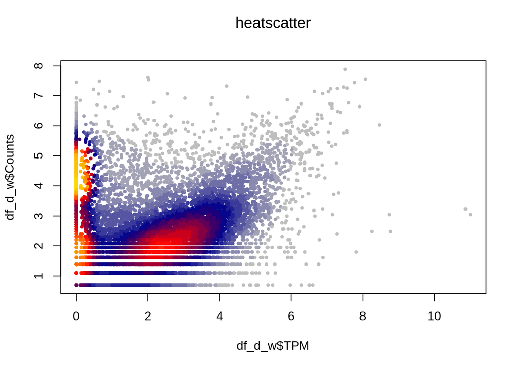

```r
heatscatter(df_d_w$TPM, df_d_w$Counts)
```

```r
cor(df_d_w$TPM, df_d_w$Counts)
```

```
## [1] -0.02325523
```

```r
length(intersect(d_w$Name, d_fuchs$Name))
```

```
## [1] 13402
```

```r
length(d_fuchs$Name)
```

```
## [1] 13413
```

```r
# how many entries intersect with Fuchs and don't have 0 counts:
num_dw_int_nc <- length(na.omit(match(d_w$Name[d_w$TPM != 0], int_d_w)))
num_d_fuchs <- length(d_fuchs$Name)
num_dw_int_nc/num_d_fuchs
```

```
## [1] 0.6649519
```

–> 66% of the Fuchs entries are found in Salmon and aren’t 0

```r
num_dw_nc <- length(d_w$TPM[d_w$TPM != 0])
num_dw_int_nc/num_dw_nc
```

```
## [1] 0.1250912
```

–> 13% of the non-cero entries overlap with Fuchs

Salmon with linear transcript finds ~5x as many counts as Fuchs. Salmon finds counts for 66% of the transcripts found by Fuchs. However, the correlation of the count values is very bad

```r
# sum of non-cero counts overlapping with Fuchs
sum_over_dw <- sum(d_w[intersect(d_w$Name[d_w$TPM != 0], int_d_w),"TPM"])
# sum of non-cero counts not overlapping with Fuchs
sum_nover_dw <- sum(d_w[setdiff(d_w$Name[d_w$TPM != 0], int_d_w),"TPM"])
sum_over_dw/(sum_over_dw + sum_nover_dw)
```

```
## [1] 0.5285255
```

–> 53% of all counts are found in the set overlapping with Fuchs (We’d love to see a high percentage here)

## Dieterich without linear transcripts

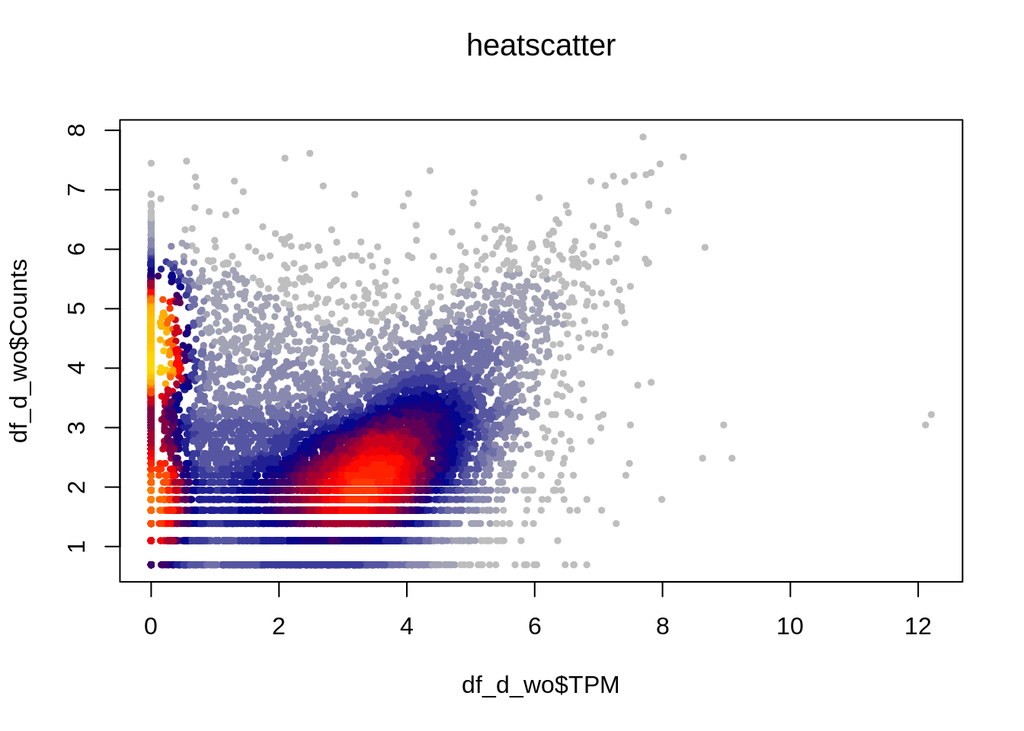

```r
heatscatter(df_d_wo$TPM, df_d_wo$Counts)
```

```r
cor(df_d_wo$TPM, df_d_wo$Counts)
```

```
## [1] -0.09416331
```

```r
length(intersect(d_wo$Name, d_fuchs$Name))
```

```
## [1] 13402
```

```r
# how many entries intersect with Fuchs and don't have 0 counts:
num_dwo_int_nc <- length(na.omit(match(d_wo$Name[d_wo$TPM != 0], int_d_wo)))
num_dwo_int_nc/num_d_fuchs
```

```
## [1] 0.6724819
```

–> 67% of the Fuchs entries are found in Salmon and aren’t 0

```r
num_dwo_nc <- length(d_wo$TPM[d_wo$TPM != 0])
num_dwo_int_nc/num_dwo_nc
```

```
## [1] 1
```

–> 100% of the non-cero entries overlap with Fuchs (naturally)

Salmon without linear transcript finds ~2/3x the counts of Fuchs (67% of the Fuchs transcripts). The correlation is still bad

## Ours with linear transcripts

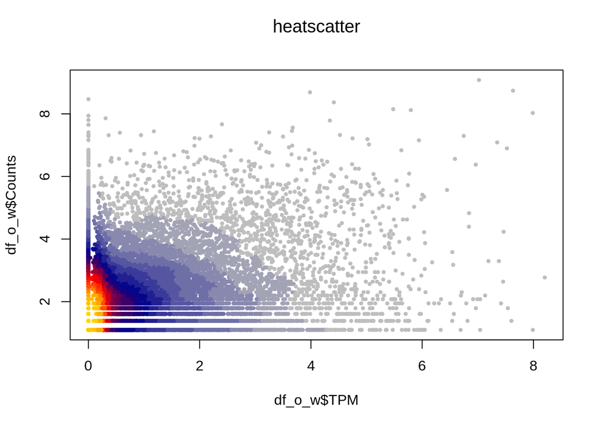

```r
heatscatter(df_o_w$TPM, df_o_w$Counts)
```

```r
cor(df_o_w$TPM, df_o_w$Counts)
```

```
## [1] 0.1679609
```

```r
length(intersect(o_w$Name, o_fuchs$Name))
```

```
## [1] 14187
```

```r
length(o_fuchs$Name)
```

```
## [1] 14496
```

```r
# how many entries intersect with Fuchs and don't have 0 counts:
num_ow_int_nc <- length(na.omit(match(o_w$Name[o_w$TPM != 0], int_o_w)))
num_o_fuchs <- length(o_fuchs$Name)
num_ow_int_nc/num_o_fuchs
```

```
## [1] 0.6187914
```

–> 62% of the Fuchs entries are found in Salmon and aren’t 0

```r
num_ow_nc <- length(o_w$TPM[o_w$TPM != 0])
num_ow_int_nc/num_ow_nc
```

```
## [1] 0.129048
```

–> 13% of the non-cero entries overlap with Fuchs

Salmon with linear transcript finds ~5x as many counts as Fuchs. Salmon finds counts for ~62% of the transcripts found by Fuchs.

```r
# sum of non-cero counts overlapping with Fuchs
sum_over_ow <- sum(o_w[intersect(o_w$Name[o_w$TPM != 0], int_o_w),"TPM"])
# sum of non-cero counts not overlapping with Fuchs
sum_nover_ow <- sum(o_w[setdiff(o_w$Name[o_w$TPM != 0], int_o_w),"TPM"])
sum_over_ow/(sum_over_ow + sum_nover_ow)
```

```
## [1] 0.17383
```

–> 17% of all counts are found in the set overlapping with Fuchs (We’d love to see a high percentage here)

## Ours without linear transcripts

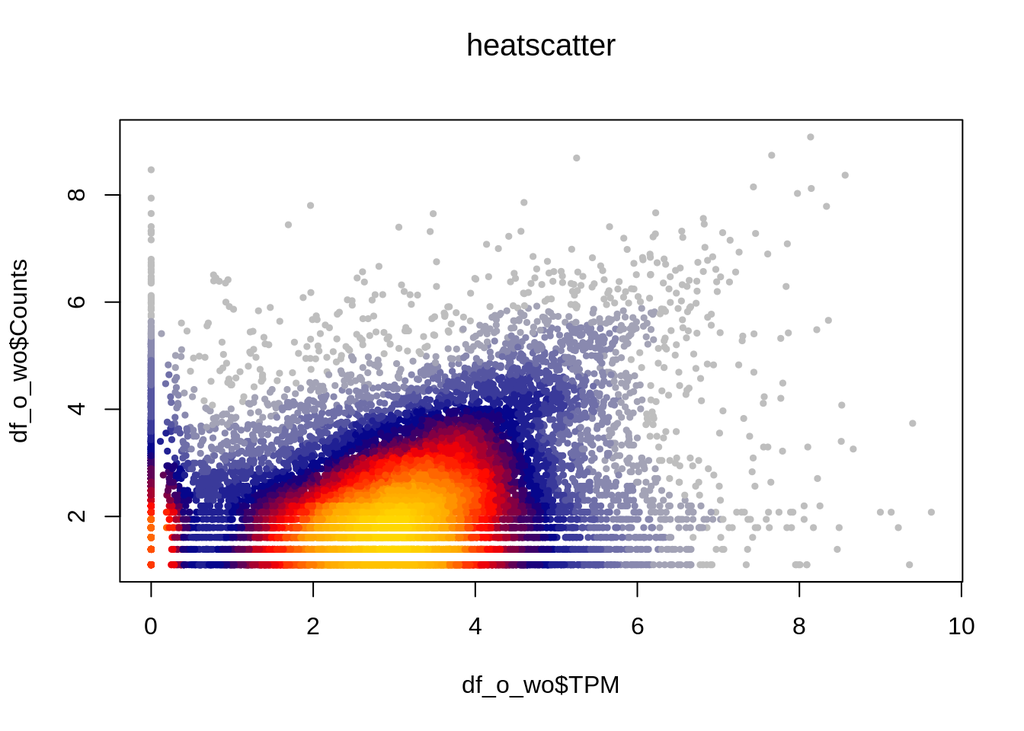

```r
heatscatter(df_o_wo$TPM, df_o_wo$Counts)
```

```r
cor(df_o_wo$TPM, df_o_wo$Counts)
```

```
## [1] 0.205908
```

```r
length(intersect(o_wo$Name, o_fuchs$Name))
```

```
## [1] 14187
```

```r
# how many entries intersect with Fuchs and don't have 0 counts:
num_owo_int_nc <- length(na.omit(match(o_wo$Name[o_wo$TPM != 0], int_o_wo)))
num_owo_int_nc/num_o_fuchs
```

```
## [1] 0.8770006
```

–> 88% of the Fuchs entries are found in Salmon and aren’t 0

```r
num_owo_nc <- length(o_wo$TPM[o_wo$TPM != 0])
num_owo_int_nc/num_owo_nc
```

```
## [1] 1
```

–> 100% of the non-cero entries overlap with Fuchs (naturally)

Salmon without linear transcript finds ~7/8x the counts of Fuchs (88% of the Fuchs transcripts).